# R Notebook

This is the first day of the R course

```r
library("readxl")
library("tidyverse")
require("tidyverse")
library("writexl")
library("psych")
library("nortest") ###REALIZA 5 PRUEBAS DE NORMALIDAD###
library("moments") ###REALIZA 1 PRUEBA DE NORMALIDAD###
```

```r
basedatos <- read_excel("PersonasConNegocios_ENIGH2022.xlsx")
```

Recodificacion de la variable usando ifelse yo pensaba usar un casewhen lol (luego voy a intentar hacer esto con tidyverse)

```r
basedatos$tamano <- as.factor(ifelse(basedatos$Numero_Empleados=='1 a 9',1,
                                     ifelse(basedatos$Numero_Empleados=='10 a 99',2,
                                            ifelse(basedatos$Numero_Empleados=='100 a 199',3,
                                                   ifelse(basedatos$Numero_Empleados=='+200',4,0)))))
attach(basedatos) #este attach no se que hace exactamente
```

```r
summary(tamano)
```

```
    0     1     2     3     4
   59 10159   506    59   171
```

```r
table(Numero_Empleados)
```

```
Numero_Empleados
     +200     1 a 9   10 a 99 100 a 199   No sabe
      171     10159       506        59        59
```

PRUEBAS DE NORMALIDAD Tiempo laborando en anios B1P02B06A

```r
basedatos$datos_normales<-rnorm(10954)
attach(basedatos)
```

```r
plot(density(datos_normales), lwd=3, col='blue', main='Gráfico de densidad', las=1,
     xlab='', ylab='Densidad')
lines(density(B1P02B06A), lwd=3, col='red')
```

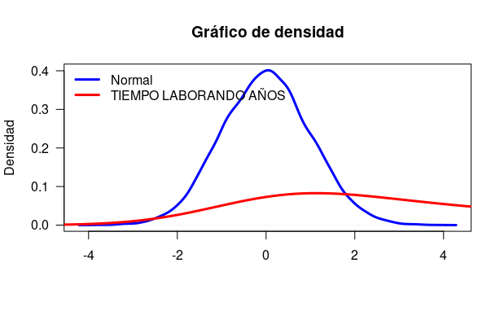

```r
legend('topleft', legend=c('Normal', 'TIEMPO LABORANDO AÑOS'),
       lwd=3, col=c('blue', 'red'), bty='n')
```

graficando en qqplot

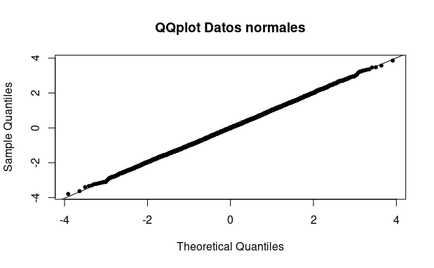

```r
qqnorm(datos_normales, pch=20,
       main='QQplot Datos normales')
qqline(datos_normales)
```

```r
#qqnorm(B1P02B06A, pch=20,
#       main='QQplot TIEMPO LABORANDO AÑOS')
#qqline(B1P02B06A)
```

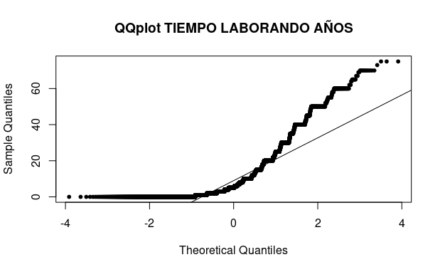

```r
qqnorm(B1P02B06A, pch=20,
       main='QQplot TIEMPO LABORANDO AÑOS')
qqline(B1P02B06A)
```

HIPOTESIS H0: La muestra proviene de una distribución normal. H1: La muestra no proviene de una distribución normal.

Para pruebas de normalidad siempre se plantean así las hipótesis. Pruebas de Normalidad del Paquete “nortest”

Prueba de Anderson-Darling

```r
ad.test(B1P02B06A)
```

```
    Anderson-Darling normality test

data:  B1P02B06A
A = 765.87, p-value < 2.2e-16
```

```r
ad.test(datos_normales)
```

```
    Anderson-Darling normality test

data:  datos_normales
A = 0.39185, p-value = 0.3787
```

Prueba de Cramer-von Mises### Es útil para pequeñas muestras y usa los momentos como criterio.###

```r
cvm.test(B1P02B06A)
```

```
    Cramer-von Mises normality test

data:  B1P02B06A
W = 134.96, p-value = 7.37e-10
```

```r
cvm.test(datos_normales)
```

```
    Cramer-von Mises normality test

data:  datos_normales
W = 0.052583, p-value = 0.474
```

Pruena de Lilliefors (Kolmogorov-Smirnov)

```r
lillie.test(B1P02B06A)
```

```
    Lilliefors (Kolmogorov-Smirnov) normality test

data:  B1P02B06A
D = 0.20508, p-value < 2.2e-16
```

```r
lillie.test(datos_normales)
```

```
    Lilliefors (Kolmogorov-Smirnov) normality test

data:  datos_normales
D = 0.0053272, p-value = 0.635
```

Prueba de Pearson chi-square### basada en una distribución Ji cuadrado y que corresponde a una prueba de bondad de ajuste.

```r
pearson.test(B1P02B06A)
```

```
    Pearson chi-square normality test

data:  B1P02B06A
P = 55034, p-value < 2.2e-16
```

```r
pearson.test(datos_normales)
```

```
    Pearson chi-square normality test

data:  datos_normales
P = 80.348, p-value = 0.4681
```

Prueba de Shapiro-Francia###

```r
sf.test(B1P02B06A[1:5000])
```

```
    Shapiro-Francia normality test

data:  B1P02B06A[1:5000]
W = 0.79621, p-value < 2.2e-16
```

```r
sf.test(datos_normales[1:5000])
```

```
    Shapiro-Francia normality test

data:  datos_normales[1:5000]
W = 0.99981, p-value = 0.9351
```

Pruebas de Normalidad del Paquete “moments” Prueba de Agostino###

```r
agostino.test(datos_normales)
```

```
    D'Agostino skewness test

data:  datos_normales
skew = 0.029282, z = 1.251729, p-value = 0.2107
alternative hypothesis: data have a skewness
```

Funciones incluidas en los paquetes básicos de R. Prueba de Shapiro-Wilk### Es más poderosa cuando se compara con otras pruebas de normalidad cuando la muestra es pequeña.

```r
shapiro.test(datos_normales[1:5000])
```

```
    Shapiro-Wilk normality test

data:  datos_normales[1:5000]
W = 0.99979, p-value = 0.9298
```

TEST DE HIPOTESIS PARA MEDIAS UNIVARIABLES se puede separar en parametrico y no parametrico H0: mu=a H1: mu distinto de a

H0: mu>a H0: mu<a

*la conclusion es la misma pero el numero no va a ser el mismo numero, son tres formas de plantear el problema

pvalor es la probabilidad que H0 sea verdad

```r
# promedio Años trabajando
mean(B1P02B06A)
```

```
[1] 11.23873
```

```r
# promedio  EDAD
mean(B1P00A03)
```

```
[1] 43.87101
```

```r
t.test(B1P02B06A, B1P00A03, alternative='two.sided',conf.level = 0.95)
```

```
    Welch Two Sample t-test

data:  B1P02B06A and B1P00A03
t = -166.08, df = 21598, p-value < 2.2e-16
alternative hypothesis: true difference in means is not equal to 0
95 percent confidence interval:
 -33.01740 -32.24716
sample estimates:
mean of x mean of y
 11.23873  43.87101
```

```r
t.test(B1P02B06A, B1P00A03, alternative='greater',conf.level = 0.95)
```

```
    Welch Two Sample t-test

data:  B1P02B06A and B1P00A03
t = -166.08, df = 21598, p-value = 1
alternative hypothesis: true difference in means is greater than 0
95 percent confidence interval:
 -32.95548       Inf
sample estimates:
mean of x mean of y
 11.23873  43.87101
```

```r
t.test(B1P02B06A, B1P00A03, alternative='less',conf.level = 0.95)
```

```
    Welch Two Sample t-test

data:  B1P02B06A and B1P00A03
t = -166.08, df = 21598, p-value < 2.2e-16
alternative hypothesis: true difference in means is less than 0
95 percent confidence interval:
      -Inf -32.30908
sample estimates:
mean of x mean of y
 11.23873  43.87101
```

```r
# promedio Años trabajando
mean(B1P02B06A)
```

```
[1] 11.23873
```

```r
# promedio  EDAD
mean(B1P00A03)
```

```
[1] 43.87101
```

```r
wilcox.test(B1P02B06A, B1P00A03, alternative='less',conf.level = 0.99)
```

```
    Wilcoxon rank sum test with continuity correction

data:  B1P02B06A and B1P00A03
W = 7782456, p-value < 2.2e-16
alternative hypothesis: true location shift is less than 0
```

**Hay que replicar el no parametrico para las variales que terminan en B1P02B24 y B1P02B25

```r
mean(B1P02B24)
```

```
[1] 1234.35
```

```r
mean(B1P02B25)
```

```
[1] 274.9346
```

```r
wilcox.test(B1P02B24, B1P02B25, alternative='two.sided',conf.level = 0.99)
```

```
    Wilcoxon rank sum test with continuity correction

data:  B1P02B24 and B1P02B25
W = 81187662, p-value < 2.2e-16
alternative hypothesis: true location shift is not equal to 0
```

```r
wilcox.test(B1P02B24, B1P02B25, alternative='greater',conf.level = 0.99)
```

```
    Wilcoxon rank sum test with continuity correction

data:  B1P02B24 and B1P02B25
W = 81187662, p-value < 2.2e-16
alternative hypothesis: true location shift is greater than 0
```

```r
wilcox.test(B1P02B24, B1P02B25, alternative='less',conf.level = 0.99)
```

```
    Wilcoxon rank sum test with continuity correction

data:  B1P02B24 and B1P02B25
W = 81187662, p-value = 1
alternative hypothesis: true location shift is less than 0
```

Comparación de las medias de más de dos grupos

Existen principalmente dos técnicas que se utilizan para comparar la media de una muestra con una media estándar conocida. Estas dos técnicas son:

Analysis of Variance (ANOVA) # One way ANOVA # Two way ANOVA # MANOVA Test

One way ANOVA El análisis de varianza unidireccional (ANOVA), también conocido como ANOVA de un factor, es una extensión de la prueba t de dos muestras independientes para comparar medias en una situación en la que hay más de dos grupos. En ANOVA unidireccional, los datos se organizan en varios grupos basados en una única variable de agrupación.

Creando variable tamaño de empresa El tamaño de la empresa: para esto puedes construir una variable categórica con las siguientes categorías: # 0= No sabe # 1= Micro empresa (1 a 9 trabajadores); # 2=Pequeña (10 a 99); # 3=Mediana (100 a 199) # 4= Grande (+200).

```r
basedatos$tamano <- as.factor(ifelse(basedatos$Numero_Empleados == '1 a 9', 1,
                                     ifelse(basedatos$Numero_Empleados == '10 a 99', 2,
                                            ifelse(basedatos$Numero_Empleados == '100 a 199', 3,
                                                   ifelse(basedatos$Numero_Empleados == '+200',4, 0 )))))
attach(basedatos)
summary(tamano)
```

```
    0     1     2     3     4
   59 10159   506    59   171
```

```r
table(Numero_Empleados)
```

```
Numero_Empleados
     +200     1 a 9   10 a 99 100 a 199   No sabe
      171     10159       506        59        59
```

# anova de B1P02B08: SUELDO O SALARIO MENSUAL

# con tamano

```r
anova_1 <- aov(B1P02B08 ~ factor(tamano))
anova_1
```

```
Call:
   aov(formula = B1P02B08 ~ factor(tamano))

Terms:
                factor(tamano)  Residuals
Sum of Squares      1316084879 5918483195
Deg. of Freedom              4       2605

Residual standard error: 1507.306
Estimated effects may be unbalanced
8344 observations deleted due to missingness
```

```r
#print(summary(anova_1))
```

```r
describeBy(B1P02B08,tamano)
```

```
 Descriptive statistics by group
group: 0
```

|  | vars | n | mean | sd | median | trimmed | mad | min | max | range | skew | kurtosis | se |
| --- | --- | --- | --- | --- | --- | --- | --- | --- | --- | --- | --- | --- | --- |
| X1 | 1 | 47 | 2703.26 | 1595.59 | 2800 | 2598.8 | 1334.34 | 200 | 9200 | 9000 | 1.24 | 3.74 | 232.74 |

```
------------------------------------------------------------------
group: 1
```

|  | vars | n | mean | sd | median | trimmed | mad | min | max | range | skew | kurtosis | se |
| --- | --- | --- | --- | --- | --- | --- | --- | --- | --- | --- | --- | --- | --- |
| X1 | 1 | 1901 | 1491.53 | 1107.58 | 1200 | 1330.08 | 711.65 | 100 | 10281 | 10181 | 3.22 | 16.74 | 25.4 |

```
------------------------------------------------------------------
group: 2
```

|  | vars | n | mean | sd | median | trimmed | mad | min | max | range | skew | kurtosis | se |
| --- | --- | --- | --- | --- | --- | --- | --- | --- | --- | --- | --- | --- | --- |
| X1 | 1 | 436 | 2451.19 | 1738.2 | 2000 | 2182.14 | 1252.8 | 100 | 10085 | 9985 | 2.01 | 5.34 | 83.24 |

```
------------------------------------------------------------------
group: 3
```

|  | vars | n | mean | sd | median | trimmed | mad | min | max | range | skew | kurtosis | se |
| --- | --- | --- | --- | --- | --- | --- | --- | --- | --- | --- | --- | --- | --- |
| X1 | 1 | 58 | 2772.91 | 1570.77 | 2800 | 2571.02 | 963.69 | 300 | 8794 | 8494 | 1.63 | 3.76 | 206.25 |

```
------------------------------------------------------------------
group: 4
```

|  | vars | n | mean | sd | median | trimmed | mad | min | max | range | skew | kurtosis | se |
| --- | --- | --- | --- | --- | --- | --- | --- | --- | --- | --- | --- | --- | --- |
| X1 | 1 | 168 | 4074.71 | 3474.15 | 3087.5 | 3532.56 | 1178.67 | 560 | 37500 | 36940 | 5.93 | 50.04 | 268.04 |

# Tukey’s Test

```r
tukey.test_1<-TukeyHSD(anova_1)
tukey.test_1
```

```
  Tukey multiple comparisons of means
    95% family-wise confidence level

Fit: aov(formula = B1P02B08 ~ factor(tamano))

$`factor(tamano)`
           diff        lwr       upr     p adj
1-0 -1211.73029 -1819.2616 -604.1989 0.0000006
2-0  -252.07350  -883.7513  379.6043 0.8121605
3-0    69.65337  -737.8529  877.1597 0.9993209
4-0  1371.44791   692.5103 2050.3855 0.0000004
2-1   959.65679   741.1780 1178.1356 0.0000000
3-1  1281.38366   732.9471 1829.8202 0.0000000
4-1  2583.17820  2252.0099 2914.3465 0.0000000
3-2   321.72687  -253.3428  896.7965 0.5448022
4-2  1623.52141  1249.8974 1997.1454 0.0000000
4-3  1301.79454   675.1810 1928.4081 0.0000002
```

[figure not shown]

```r
basedatos$trabajos <- as.factor(ifelse(basedatos$B1P02B01 == 'UN SOLO TRABAJO', 1,
                                                         ifelse(basedatos$B1P02B01 == 'DOS TRABAJOS', 2, 3)))
attach(basedatos)
table(B1P02B01)
```

```
B1P02B01
       DOS TRABAJOS TRES O MAS TRABAJOS     UN SOLO TRABAJO
               4486                 208                6260
```

```r
table(trabajos)
```

```
trabajos
   1    2    3
6260 4486  208
```

```r
# anova de B1P02B08: SUELDO O SALARIO MENSUAL
# con tamano
anova_2 <- aov(B1P02B08 ~ factor(trabajos))
anova_2
```

```
Call:
   aov(formula = B1P02B08 ~ factor(trabajos))

Terms:
                factor(trabajos)  Residuals
Sum of Squares           2361088 7232206986
Deg. of Freedom                1       2608

Residual standard error: 1665.258
Estimated effects may be unbalanced
8344 observations deleted due to missingness
```

```r
print(summary(anova_2))
```

```
                   Df    Sum Sq Mean Sq F value Pr(>F)
factor(trabajos)    1 2.361e+06 2361088   0.851  0.356
Residuals        2608 7.232e+09 2773086
8344 observations deleted due to missingness
```

```r
describeBy(B1P02B08,trabajos)
```

```
 Descriptive statistics by group
group: 1
```

|  | vars | n | mean | sd | median | trimmed | mad | min | max | range | skew | kurtosis | se |
| --- | --- | --- | --- | --- | --- | --- | --- | --- | --- | --- | --- | --- | --- |
| X1 | 1 | 0 | NaN | NA | NA | NaN | NA | Inf | -Inf | -Inf | NA | NA | NA |

```
------------------------------------------------------------------
group: 2
```

|  | vars | n | mean | sd | median | trimmed | mad | min | max | range | skew | kurtosis | se |
| --- | --- | --- | --- | --- | --- | --- | --- | --- | --- | --- | --- | --- | --- |
| X1 | 1 | 2518 | 1862.66 | 1650.91 | 1440 | 1611.88 | 889.56 | 100 | 37500 | 37400 | 6.08 | 94.1 | 32.9 |

```
------------------------------------------------------------------
group: 3
```

|  | vars | n | mean | sd | median | trimmed | mad | min | max | range | skew | kurtosis | se |
| --- | --- | --- | --- | --- | --- | --- | --- | --- | --- | --- | --- | --- | --- |
| X1 | 1 | 92 | 2025.76 | 2022.08 | 1400 | 1616.96 | 889.56 | 300 | 10000 | 9700 | 2.44 | 6.29 | 210.82 |

```r
tukey.test_2
```

```
  Tukey multiple comparisons of means
    95% family-wise confidence level

Fit: aov(formula = B1P02B08 ~ factor(trabajos))

$`factor(trabajos)`
        diff       lwr      upr     p adj
3-2 163.1002 -183.5008 509.7012 0.3562335
```

[figure not shown]